# `table`

Element

A table of items.

Tables are used to arrange content in cells. Cells can contain arbitrary content, including multiple paragraphs and are specified in row-major order. For a hands-on explanation of all the ways you can use and customize tables in Typst, check out the [Table Guide](https://typst.app/docs/guides/tables/).

Because tables are just grids with different defaults for some cell properties (notably `stroke` and `inset`), refer to the grid documentation for more information on how to size the table tracks and specify the cell appearance properties.

If you are unsure whether you should be using a table or a grid, consider whether the content you are arranging semantically belongs together as a set of related data points or similar or whether you are just want to enhance your presentation by arranging unrelated content in a grid. In the former case, a table is the right choice, while in the latter case, a grid is more appropriate. Furthermore, Assistive Technology (AT) like screen readers will announce content in a `table` as tabular while a grid’s content will be announced no different than multiple content blocks in the document flow. AT users will be able to navigate tables two-dimensionally by cell.

Note that, to override a particular cell’s properties or apply show rules on table cells, you can use the `table.cell` element. See its documentation for more information.

Although the `table` and the `grid` share most properties, set and show rules on one of them do not affect the other. Locating most of your styling in set and show rules is recommended, as it keeps the table’s actual usages clean and easy to read. It also allows you to easily change the appearance of all tables in one place.

To give a table a caption and make it referenceable, put it into a figure.

## Example

The example below demonstrates some of the most common table options.

```
#table(
  columns: (1fr, auto, auto),
  inset: 10pt,
  align: horizon,
  table.header(
    [], [*Volume*], [*Parameters*],
  ),
  image("cylinder.svg"),
  $ pi h (D^2 - d^2) / 4 $,
  [
    $h$: height \
    $D$: outer radius \
    $d$: inner radius
  ],
  image("tetrahedron.svg"),
  $ sqrt(2) / 12 a^3 $,
  [$a$: edge length]
)
```

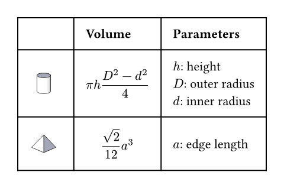

Much like with grids, you can use `table.cell` to customize the appearance and the position of each cell.

```
#set table(
  stroke: none,
  gutter: 0.2em,
  fill: (x, y) =>
    if x == 0 or y == 0 { gray },
  inset: (right: 1.5em),
)

#show table.cell: it => {
  if it.x == 0 or it.y == 0 {
    set text(white)
    strong(it)
  } else if it.body == [] {
    // Replace empty cells with 'N/A'
    pad(..it.inset)[_N/A_]
  } else {
    it
  }
}

#let a = table.cell(
  fill: green.lighten(60%),
)[A]
#let b = table.cell(
  fill: aqua.lighten(60%),
)[B]

#table(
  columns: 4,
  [], [Exam 1], [Exam 2], [Exam 3],

  [John], [], a, [],
  [Mary], [], a, a,
  [Robert], b, a, b,
)
```

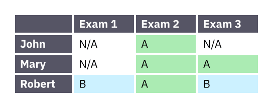

## Accessibility

Tables are challenging to consume for users of Assistive Technology (AT). To make the life of AT users easier, we strongly recommend that you use `table.header` and `table.footer` to mark the header and footer sections of your table. This will allow AT to announce the column labels for each cell.

Because navigating a table by cell is more cumbersome than reading it visually, you should consider making the core information in your table available as text as well. You can do this by wrapping your table in a figure and using its caption to summarize the table’s content.

## Parameters

```
table(
  columns: auto or int or relative or fraction or array,
  rows: auto or int or relative or fraction or array,
  gutter: auto or int or relative or fraction or array,
  column-gutter: auto or int or relative or fraction or array,
  row-gutter: auto or int or relative or fraction or array,
  inset: relative or array or dictionary or function,
  align: auto or array or function or alignment,
  fill: none or color or gradient or tiling or array or function,
  stroke: none or length or color or gradient or stroke or tiling or array or dictionary or function,
  ..content,
) → content
```

### `columns`

auto or int or relative or fraction or array Settable

Default: `()`

The column sizes. See the grid documentation for more information on track sizing.

### `rows`

auto or int or relative or fraction or array Settable

Default: `()`

The row sizes. See the grid documentation for more information on track sizing.

### `gutter`

auto or int or relative or fraction or array

Default: `()`

The gaps between rows and columns. This is a shorthand for setting `column-gutter` and `row-gutter` to the same value. See the grid documentation for more information on gutters.

### `column-gutter`

auto or int or relative or fraction or array Settable

Default: `()`

The gaps between columns. Takes precedence over `gutter`. See the grid documentation for more information on gutters.

### `row-gutter`

auto or int or relative or fraction or array Settable

Default: `()`

The gaps between rows. Takes precedence over `gutter`. See the grid documentation for more information on gutters.

### `inset`

relative or array or dictionary or function Settable

Default: `0% + 5pt`

How much to pad the cells’ content.

To specify the same inset for all cells, use a single length for all sides, or a dictionary of lengths for individual sides. See the box’s documentation for more details.

To specify a varying inset for different cells, you can:

- use a single, uniform inset for all cells
- use an array of insets for each column
- use a function that maps a cell’s X/Y position (both starting from zero) to its inset

See the grid documentation for more details.

**View example**

```
#table(
  columns: 2,
  inset: 10pt,
  [Hello],
  [World],
)

#table(
  columns: 2,
  inset: (x: 20pt, y: 10pt),
  [Hello],
  [World],
)
```

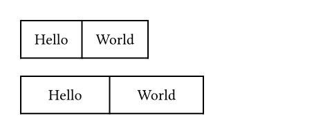

### `align`

auto or array or function or alignment Settable

Default: `auto`

How to align the cells’ content.

If set to `auto`, the outer alignment is used.

You can specify the alignment in any of the following fashions:

- use a single alignment for all cells
- use an array of alignments corresponding to each column
- use a function that maps a cell’s X/Y position (both starting from zero) to its alignment

See the [Table Guide](https://typst.app/docs/guides/tables/#alignment) for details.

**View example**

```
#table(
  columns: 3,
  align: (left, center, right),
  [Hello], [Hello], [Hello],
  [A], [B], [C],
)
```

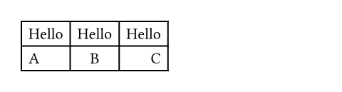

### `fill`

none or color or gradient or tiling or array or function Settable

Default: `none`

How to fill the cells.

This can be:

- a single fill for all cells
- an array of fill corresponding to each column
- a function that maps a cell’s position to its fill

Most notably, arrays and functions are useful for creating striped tables. See the [Table Guide](https://typst.app/docs/guides/tables/#fills) for more details.

**View example**

```
#table(
  fill: (x, _) =>
    if calc.odd(x) { luma(240) }
    else { white },
  align: (x, y) =>
    if y == 0 { center }
    else if x == 0 { left }
    else { right },
  columns: 4,
  [], [*Q1*], [*Q2*], [*Q3*],
  [Revenue:], [1000 €], [2000 €], [3000 €],
  [Expenses:], [500 €], [1000 €], [1500 €],
  [Profit:], [500 €], [1000 €], [1500 €],
)
```

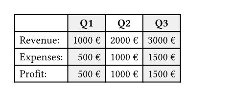

### `stroke`

none or length or color or gradient or stroke or tiling or array or dictionary or function Settable

Default: `1pt + black`

How to stroke the cells.

Strokes can be disabled by setting this to `none`.

If it is necessary to place lines which can cross spacing between cells produced by the `gutter` option, or to override the stroke between multiple specific cells, consider specifying one or more of `table.hline` and `table.vline` alongside your table cells.

To specify the same stroke for all cells, use a single stroke for all sides, or a dictionary of strokes for individual sides. See the rectangle’s documentation for more details.

To specify varying strokes for different cells, you can:

- use a single stroke for all cells
- use an array of strokes corresponding to each column
- use a function that maps a cell’s position to its stroke

See the [Table Guide](https://typst.app/docs/guides/tables/#strokes) for more details.

### `children`

content Required Positional Variadic

The contents of the table cells, plus any extra table lines specified with the `table.hline` and `table.vline` elements.

## Definitions

### `cell`

Element

A cell in the table. Use this to position a cell manually or to apply styling. To do the latter, you can either use the function to override the properties for a particular cell, or use it in show rules to apply certain styles to multiple cells at once.

Perhaps the most important use case of `table.cell` is to make a cell span multiple columns and/or rows with the `colspan` and `rowspan` fields.

**View example**

```
#show table.cell.where(y: 0): strong
#set table(
  stroke: (x, y) => if y == 0 {
    (bottom: 0.7pt + black)
  },
  align: (x, y) => (
    if x > 0 { center }
    else { left }
  )
)

#table(
  columns: 3,
  table.header(
    [Substance],
    [Subcritical °C],
    [Supercritical °C],
  ),
  [Hydrochloric Acid],
  [12.0], [92.1],
  [Sodium Myreth Sulfate],
  [16.6], [104],
  [Potassium Hydroxide],
  table.cell(colspan: 2)[24.7],
)
```

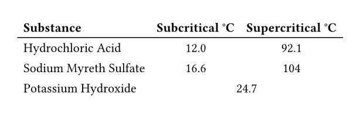

For example, you can override the fill, alignment or inset for a single cell:

**View example**

```
// You can also import those.
#import table: cell, header

#table(
  columns: 2,
  align: center,
  header(
    [*Trip progress*],
    [*Itinerary*],
  ),
  cell(
    align: right,
    fill: fuchsia.lighten(80%),
    [🚗],
  ),
  [Get in, folks!],
  [🚗], [Eat curbside hotdog],
  cell(align: left)[🌴🚗],
  cell(
    inset: 0.06em,
    text(1.62em)[🏝️🌅🌊],
  ),
)
```

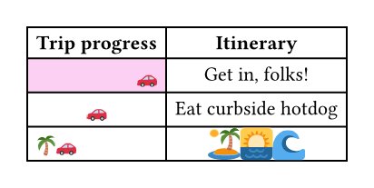

You may also apply a show rule on `table.cell` to style all cells at once. Combined with selectors, this allows you to apply styles based on a cell’s position:

**View example**

```
#show table.cell.where(x: 0): strong

#table(
  columns: 3,
  gutter: 3pt,
  [Name], [Age], [Strength],
  [Hannes], [36], [Grace],
  [Irma], [50], [Resourcefulness],
  [Vikram], [49], [Perseverance],
)
```

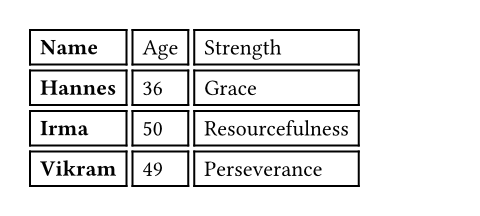

```
table.cell(
  content,
  x: auto or int,
  y: auto or int,
  colspan: int,
  rowspan: int,
  inset: auto or relative or dictionary,
  align: auto or alignment,
  fill: none or auto or color or gradient or tiling,
  stroke: none or length or color or gradient or stroke or tiling or dictionary,
  breakable: auto or bool,
) → content
```

#### `body`

content Required Positional

The cell’s body.

#### `x`

auto or int Settable

Default: `auto`

The cell’s column (zero-indexed). Functions identically to the `x` field in `grid.cell`.

#### `y`

auto or int Settable

Default: `auto`

The cell’s row (zero-indexed). Functions identically to the `y` field in `grid.cell`.

#### `colspan`

int Settable

Default: `1`

The amount of columns spanned by this cell.

#### `rowspan`

int Settable

Default: `1`

The amount of rows spanned by this cell.

#### `inset`

auto or relative or dictionary Settable

Default: `auto`

The cell’s inset override.

#### `align`

auto or alignment Settable

Default: `auto`

The cell’s alignment override.

#### `fill`

none or auto or color or gradient or tiling Settable

Default: `auto`

The cell’s fill override.

#### `stroke`

none or length or color or gradient or stroke or tiling or dictionary Settable

Default: `(:)`

The cell’s stroke override.

#### `breakable`

auto or bool Settable

Default: `auto`

Whether rows spanned by this cell can be placed in different pages. When equal to `auto`, a cell spanning only fixed-size rows is unbreakable, while a cell spanning at least one `auto`-sized row is breakable.

### `hline`

Element

A horizontal line in the table.

Overrides any per-cell stroke, including stroke specified through the table’s `stroke` field. Can cross spacing between cells created through the table’s `column-gutter` option.

Use this function instead of the table’s `stroke` field if you want to manually place a horizontal line at a specific position in a single table. Consider using table’s `stroke` field or `table.cell`’s `stroke` field instead if the line you want to place is part of all your tables’ designs.

**View example**

```
#set table.hline(stroke: .6pt)

#table(
  stroke: none,
  columns: (auto, 1fr),
  [09:00], [Badge pick up],
  [09:45], [Opening Keynote],
  [10:30], [Talk: Typst's Future],
  [11:15], [Session: Good PRs],
  table.hline(start: 1),
  [Noon], [_Lunch break_],
  table.hline(start: 1),
  [14:00], [Talk: Tracked Layout],
  [15:00], [Talk: Automations],
  [16:00], [Workshop: Tables],
  table.hline(),
  [19:00], [Day 1 Attendee Mixer],
)
```

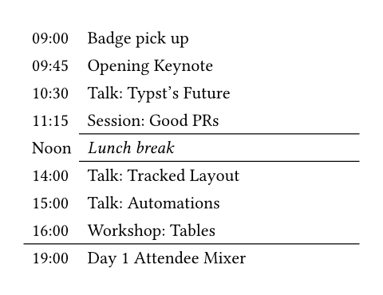

```
table.hline(
  y: auto or int,
  start: int,
  end: none or int,
  stroke: none or length or color or gradient or stroke or tiling or dictionary,
  position: alignment,
) → content
```

#### `y`

auto or int Settable

Default: `auto`

The row above which the horizontal line is placed (zero-indexed). Functions identically to the `y` field in `grid.hline`.

#### `start`

int Settable

Default: `0`

The column at which the horizontal line starts (zero-indexed, inclusive).

#### `end`

none or int Settable

Default: `none`

The column before which the horizontal line ends (zero-indexed, exclusive).

#### `stroke`

none or length or color or gradient or stroke or tiling or dictionary Settable

Default: `1pt + black`

The line’s stroke.

Specifying `none` removes any lines previously placed across this line’s range, including hlines or per-cell stroke below it.

#### `position`

alignment Settable

Default: `top`

The position at which the line is placed, given its row (`y`) - either `top` to draw above it or `bottom` to draw below it.

This setting is only relevant when row gutter is enabled (and shouldn’t be used otherwise - prefer just increasing the `y` field by one instead), since then the position below a row becomes different from the position above the next row due to the spacing between both.

### `vline`

Element

A vertical line in the table. See the docs for `grid.vline` for more information regarding how to use this element’s fields.

Overrides any per-cell stroke, including stroke specified through the table’s `stroke` field. Can cross spacing between cells created through the table’s `row-gutter` option.

Similar to `table.hline`, use this function if you want to manually place a vertical line at a specific position in a single table and use the table’s `stroke` field or `table.cell`’s `stroke` field instead if the line you want to place is part of all your tables’ designs.

```
table.vline(
  x: auto or int,
  start: int,
  end: none or int,
  stroke: none or length or color or gradient or stroke or tiling or dictionary,
  position: alignment,
) → content
```

#### `x`

auto or int Settable

Default: `auto`

The column before which the vertical line is placed (zero-indexed). Functions identically to the `x` field in `grid.vline`.

#### `start`

int Settable

Default: `0`

The row at which the vertical line starts (zero-indexed, inclusive).

#### `end`

none or int Settable

Default: `none`

The row on top of which the vertical line ends (zero-indexed, exclusive).

#### `stroke`

none or length or color or gradient or stroke or tiling or dictionary Settable

Default: `1pt + black`

The line’s stroke.

Specifying `none` removes any lines previously placed across this line’s range, including vlines or per-cell stroke below it.

#### `position`

alignment Settable

Default: `start`

The position at which the line is placed, given its column (`x`) - either `start` to draw before it or `end` to draw after it.

The values `left` and `right` are also accepted, but discouraged as they cause your table to be inconsistent between left-to-right and right-to-left documents.

This setting is only relevant when column gutter is enabled (and shouldn’t be used otherwise - prefer just increasing the `x` field by one instead), since then the position after a column becomes different from the position before the next column due to the spacing between both.

### `header`

Element

A repeatable table header.

You should wrap your tables’ heading rows in this function even if you do not plan to wrap your table across pages because Typst uses this function to attach accessibility metadata to tables and ensure [Universal Access](https://typst.app/docs/guides/accessibility/#basics) to your document.

You can use the `repeat` parameter to control whether your table’s header will be repeated across pages.

Currently, this function is unsuitable for creating a header column or single header cells. Either use regular cells, or, if you are exporting a PDF, you can also use the `pdf.header-cell` function to mark a cell as a header cell. Likewise, you can use `pdf.data-cell` to mark cells in this function as data cells. Note that these functions are not final and thus only available when you enable the `a11y-extras` feature (see the PDF module documentation for details).

**View example**

```
#set page(height: 11.5em)
#set table(
  fill: (x, y) =>
    if x == 0 or y == 0 {
      gray.lighten(40%)
    },
  align: right,
)

#show table.cell.where(x: 0): strong
#show table.cell.where(y: 0): strong

#table(
  columns: 4,
  table.header(
    [], [Blue chip],
    [Fresh IPO], [Penny st'k],
  ),
  table.cell(
    rowspan: 6,
    align: horizon,
    rotate(-90deg, reflow: true)[
      *USD / day*
    ],
  ),
  [0.20], [104], [5],
  [3.17], [108], [4],
  [1.59], [84],  [1],
  [0.26], [98],  [15],
  [0.01], [195], [4],
  [7.34], [57],  [2],
)
```

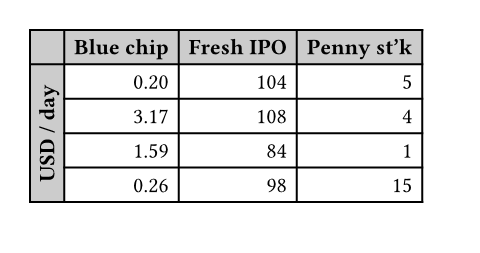

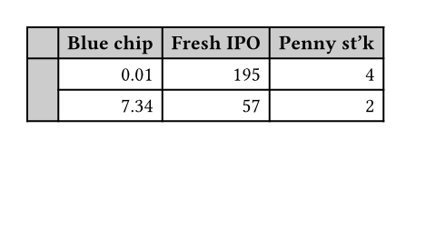

```
table.header(
  repeat: bool,
  level: int,
  ..content,
) → content
```

#### `repeat`

bool Settable

Default: `true`

Whether this header should be repeated across pages.

#### `level`

int Settable

Default: `1`

The level of the header. Must not be zero.

This allows repeating multiple headers at once. Headers with different levels can repeat together, as long as they have ascending levels.

Notably, when a header with a lower level starts repeating, all higher or equal level headers stop repeating (they are “replaced” by the new header).

#### `children`

content Required Positional Variadic

The cells and lines within the header.

### `footer`

Element

A repeatable table footer.

Just like the `table.header` element, the footer can repeat itself on every page of the table. This is useful for improving legibility by adding the column labels in both the header and footer of a large table, totals, or other information that should be visible on every page.

No other table cells may be placed after the footer.

```
table.footer(
  repeat: bool,
  ..content,
) → content
```

#### `repeat`

bool Settable

Default: `true`

Whether this footer should be repeated across pages.

#### `children`

content Required Positional Variadic

The cells and lines within the footer.

© Typst GmbH and contributors  
Licensed under the Apache License, Version 2.0.  
https://typst.app/docs/reference/model/table/